# Class 4 - Functional Programming

June 12, 2020

## Required Libraires

- `tidyverse`: includes all the required packages for function writing

```r
library(pacman)
p_load(tidyverse)
```

## Outline for today

- Introduction to functions
  - Syntax of a function
  - Basic functions
- Control Flow Function Writing
  - `if`, `else` and `else if` statements
- Iterative Function Writing
  - `for` and `while` loops
  - `break` and `next`
- Functional Programming

## What is a function?

- Functions are ways to **automate** repeated / commonly-used actions
- They make programming more convenient and efficient
- Functions are recommended over copying and pasting code
  - They can help to reduce / prevent potential errors from copying and pasting code
  - The general rule of thumb is to use a function if you are copying and pasting a block of code more than twice

## Syntax of a Function

- A Function is always made up of **3 main parts**:
  - **Function Name**, must be assigned and used in conjunction with `function()`
  - **Function Arguments**, within the ( … )
  - **Function Body**, within the { … }

```r
# Syntax of a function
function_name <- function(argument_1, argument_2) {
  body_of_the_function
}
```

## Sample Function

- In this example, we create a function that **adds numbers** together
- The function name is `addition`
- The function takes 2 arguments, `number_1` and `number_2`
- The output of the function is the `sum`, which we use `return()` to produce the output

```r
# Sample Addition Function
addition <- function(number_1, number_2) {
  sum <- number_1 + number_2
  return(sum)
}
```

```r
# Run the function
addition(4, 5)
```

```
## [1] 9
```

## Another Sample Function

- This function can be used to **calculate the speed of an object**
- The formula for speed is \(speed = distance / time\)

```r
# Build a function to calculate Speed
speedR <- function(distance, time) {
  speed <- distance / time
  return(paste("Speed is", speed, "km per hour"))
  }
```

```r
# Run the function for 120km in 2 hours
speedR(120, 2)
```

```
## [1] "Speed is 60 km per hour"
```

```r
# Run the function for 600km in 3 hours
speedR(distance = 600, time = 3)
```

```
## [1] "Speed is 200 km per hour"
```

## Your turn to try!

- Can you try writing a function to **convert km into miles?**
- 1km = 0.621371 miles
- Remember, a function requires 3 main components
  - Name
  - Arguments
  - Body
- Test the function for 20 km

## Your turn to try!

```r
km_to_miles <- function(km) {
  miles <- km * 0.621371
  return(miles)
}
```

```r
# Run the function
km_to_miles(20)
```

```
## [1] 12.42742
```

## Your turn to try!

- Can you try writing a function to **square a number**
- Remember, a function requires 3 main components
  - Name
  - Arguments
  - Body
- Test the function for 16

## Your turn to try!

```r
square_this <- function(number) {
  return(number ^ 2)
}
```

```r
# Run the function
square_this(16)
```

```
## [1] 256
```

## Setting Default Arguments

- Function `to_the_power` allows us to take 2 numbers - x and y and produce a result of x ^ y

```r
# We can also set arguments to a default value
# In this example, we set the default to 2, i.e. square an object
to_the_power <- function(number, by = 2) {
  return(number ^ by)
}
```

```r
# If we only state one number, the function will default to square
to_the_power(2)
```

```
## [1] 4
```

```r
# If we state 2 numbers, the function will follow accordingly
# In this case, 2 ^ 3
to_the_power(2, by = 3)
```

```
## [1] 8
```

## Control Flow Function Writing

- Control Flow Statements help us to execute functions based on conditions
  - They help to automate decision making
- You can use `if`, `else`, `else if`
- This can be useful if we only want to run the function if certain conditions are met, e.g. TRUE or FALSE values / string matches / numerical conditions

## Control Flow - `if` statement

- `if` statement is used for a stated condition
- It will work for TRUE or FALSE, matches or numerical conditions

```r
# if statement for positive / negative number
x <- 5 # let x be 5
if(x > 0){
print("Positive number")
}
```

```
## [1] "Positive number"
```

```r
# if statement for string matches
x <- "Does this match?"
if(x == "Does this match?"){
print("Yes it does!")
}
```

```
## [1] "Yes it does!"
```

## Control Flow - `else` statement

- The `else` statement can be used to specify an action when the `if` condition is not met
- Needs to be used in conjunciton with the `if` statement

```r
x <- -5 # When the condition is not met there will be no output
if(x > 0){
print("Positive number")
}
```

```r
x <-  - 5 # let x be 5
if(x > 0){
print("Positive number")
} else { # When the condition is not met, print something else
  print("negative number")
}
```

```
## [1] "negative number"
```

## Control Flow - `else if` statement

- Use `else if` if there are additional conditions

```r
x <-  0 # let x be 5
if(x > 0){
print("Positive number")
} else if (x < 0) {
  print("negative number")
} else {
  print("x = 0")
}
```

```
## [1] "x = 0"
```

## Control Flow - if & else statement

- Using the `if` & `else` statement to recode variables
- Can use the short form version of `ifelse`

```r
# Transmission of vehicles in mtcars dataset
mtcars$am
```

```
##  [1] 1 1 1 0 0 0 0 0 0 0 0 0 0 0 0 0 0 1 1 1 0 0 0 0 0 1 1 1 1 1 1 1
```

```r
# Recode variables by using ifelse
mtcars$am <- ifelse(mtcars$am == 0, "automatic", "manual")
mtcars$am
```

```
##  [1] "manual"    "manual"    "manual"    "automatic" "automatic" "automatic"
##  [7] "automatic" "automatic" "automatic" "automatic" "automatic" "automatic"
## [13] "automatic" "automatic" "automatic" "automatic" "automatic" "manual"
## [19] "manual"    "manual"    "automatic" "automatic" "automatic" "automatic"
## [25] "automatic" "manual"    "manual"    "manual"    "manual"    "manual"
## [31] "manual"    "manual"
```

## Your turn to try!

- Can you build a if else function to see if a number is even or odd?
  - hint: `%%` gives you the remainder of a number

```r
# example
4 %% 2 # remainder of 4 / 2
```

```
## [1] 0
```

```r
9 %% 2 # remainder of 9 / 2
```

```
## [1] 1
```

## Your turn to try!

```r
x <-
if (x %% 2 == 0) {
  print("number is even")
} else {
  print("number is odd")
}
```

```
## [1] "number is even"
```

## Iterative Function Writing - `for` loops

- Loops are used to repeat a sequence of instructions under specified conditions. They provide a means to automate parts of your code that are repeated.
- A `for` loop is used when you know exactly how many times you want to execute a code
  - E.g. Run a loop for all the columns in your dataset

## Iterative Function Writing - `for` loops

- Syntax of a `for` loop

```r
for (value in sequence) {
  body
}
```

- A sequence can be created via `seq` or `:`

```r
# Create a sequence with seq()
seq(2010, 2014)
```

```
## [1] 2010 2011 2012 2013 2014
```

```r
# You can also use ':'
2010:2014
```

```
## [1] 2010 2011 2012 2013 2014
```

## Application of `for` loops

- Instead of writing / running a similar code multiple times, write an iterative loop

```r
# Print the year
print(paste("The year is", 2010))
```

```
## [1] "The year is 2010"
```

```r
print(paste("The year is", 2011))
```

```
## [1] "The year is 2011"
```

```r
print(paste("The year is", 2012))
```

```
## [1] "The year is 2012"
```

## Application of `for` loops

```r
for(i in seq(2010, 2014)) {
  print(paste("The year is", i))
}
```

```
## [1] "The year is 2010"
## [1] "The year is 2011"
## [1] "The year is 2012"
## [1] "The year is 2013"
## [1] "The year is 2014"
```

## Application of `for` loops

```r
numbers <- c(1, 3, 5, 2, 8, 9, 11, 13, 12) # Create a list of numbers
for (number in numbers) {
  if (number %% 2 == 0) { # if remainder of dividing by 2 == 0
    print(paste(number, "is even"))
  } else {
    print(paste(number, "is odd"))
  }
}
```

```
## [1] "1 is odd"
## [1] "3 is odd"
## [1] "5 is odd"
## [1] "2 is even"
## [1] "8 is even"
## [1] "9 is odd"
## [1] "11 is odd"
## [1] "13 is odd"
## [1] "12 is even"
```

## Application of `for` loops

- Lets use `for` loop to conduct a *Bernoulli experiment*
- Imagine tossing a fair coin 10 times in a row
- Can you guess how likely will the outcome be 5 heads and 5 tails?
- What is the probability that the outcome will be 5 heads and 5 tails?

```r
# Let's say we flip a Coin 10 times
sample(c("Heads", "Tails"), 10, rep = TRUE) # rep stands for replace
```

```
##  [1] "Tails" "Heads" "Heads" "Heads" "Tails" "Heads" "Tails" "Tails" "Tails"
## [10] "Tails"
```

## Application of `for` loops

- In this case, we want to calculate \(P(k|n, p)\) where k is the likelihood of observing 5 heads, n is the number of coin flips, i.e. 10 times and p is the probability of getting a head from a fair coin, i.e. 50-50
- In R, we can use the `dbinom()` function to calculate this probability
- From the chunk below, can see that the probability of observing Head \(k = 5\) times when tossing a fair coin \(n = 10\) is about 24.6%

```r
# Check probability of 5 heads and 5 tails
dbinom(x = 5, size = 10, prob = 0.5)
```

```
## [1] 0.2460938
```

```r
# How many heads do we get in 10 flips?
sum(sample(c("Heads", "Tails"), 10, rep = TRUE) == "Heads")
```

```
## [1] 5
```

## Application of `for` loops

- Let’s use a `for` loop to play with this experiment
- Flip the coin 10 times and tabulate the number of heads
- Let’s do this 10 more times, i.e. flip the coin 100 times in total
- We need to first create an empty list to initializes our variable. This creates a spot in the memory to contain all the outcomes

```r
# Create an empty list called number of heads that will contain the results from our coin toss
number_of_heads <- c()

# Run the Function for 10 Tries
for(i in 1:10) {
  number_of_heads[i] <- sum(sample(c("Heads", "Tails"), 10, rep = TRUE) == "Heads")
}
```

```r
# Print the number of heads for each of the 10 tries
print(number_of_heads)
```

```
##  [1] 9 8 6 5 3 6 5 5 5 5
```

## Application of `for` loops

- Can you describe the distribution of this histogram?

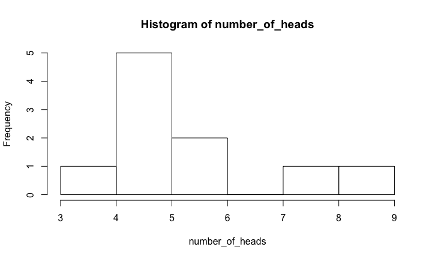

```r
# Plot a histogram of our output from the 10 tries
hist(number_of_heads)
```

## Application of `for` loops

- Let’s try running the same experiment but this time for 10,000 tries
- Notice how easy `for` loops allow us to scale up the process?

```r
# Create an empty list called number of heads that will contain the results from our coin toss
number_of_heads <- c()

# Run the Function for 10,000 Tries
for(i in 1:10000) {
  number_of_heads[i] <- sum(sample(c("Heads", "Tails"), 10, rep = TRUE) == "Heads")
}
```

```r
head(number_of_heads)
```

```
## [1] 5 6 4 4 9 5
```

```r
length(number_of_heads)
```

```
## [1] 10000
```

## Application of `for` loops

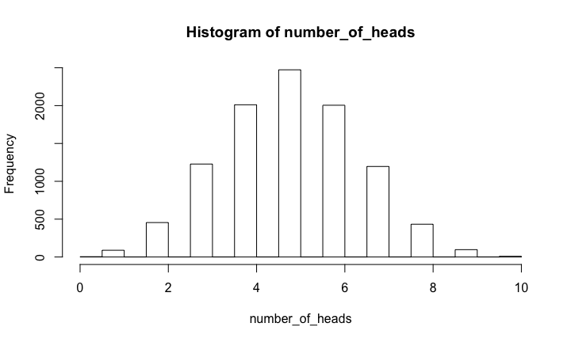

```r
# Print the histogram of our output for 10,000 tries
hist(number_of_heads)
```

## Iterative Function Writing - `while` loops

- `while` loops are used to iterate until a logical statement returns FALSE
- `while` loops begin by testing a condition. If it is true, then they execute the statement. Once the statement is executed, the condition is tested again, and so forth, until the condition is false, after which the loop exits
- Syntax of while loop:

```r
while(test_expression) {
  statement
  }
```

## Application of `while` loops

```r
counter <- 1 # Set a counter
while(counter <= 10) { # Run the while loop until counter is 10
  print(counter)
  counter <- counter + 1 # Increase the counter everytime the loop runs
}
```

```
## [1] 1
## [1] 2
## [1] 3
## [1] 4
## [1] 5
## [1] 6
## [1] 7
## [1] 8
## [1] 9
## [1] 10
```

## Application of `break`

- A `break` can be used inside a loop to stop the iterations
- This is a useful task to control the flow of the loop or to stop the function from running when there are errors

```r
x <- -5:5 # Create a sequence -5 to 5
for (val in x) {
  print(val)
  if(val == 0) {
    break # Stop at zero using the break
  }
}
```

```
## [1] -5
## [1] -4
## [1] -3
## [1] -2
## [1] -1
## [1] 0
```

## Application of `break` for error resolution

```r
# In this case, an error came up because "A" cannot be multiplied
# The function will not run
x <- list(1, 2, 3, 4, "A", 5, 6, 7)
for (val in x) {
  print(val * 2)
}
```

## Application of `break` for error resolution

- We can use `break` to run the function but stop at the error

```r
x <- list(1, 2, 3, 4, "A", 5, 6, 7)
for (val in x) {
  if(is.numeric(val) != TRUE) {
    break # Use break to stop the function when an error occurs
  }
  print(val * 2)
}
```

```
## [1] 2
## [1] 4
## [1] 6
## [1] 8
```

## Application of `next` for error resolution

- We can also use `next` to “SKIP” over the error

```r
x <- list(1, 2, 3, 4, "A", 5, 6, 7)
for (val in x) {
  if(is.numeric(val) != TRUE) {
    next # Use next to skip the error and continue
  }
  print(val * 2)
}
```

```
## [1] 2
## [1] 4
## [1] 6
## [1] 8
## [1] 10
## [1] 12
## [1] 14
```

## Functional Programming - `apply()`

- `apply()` function acts like loops but they work within the dataframe across rows or columns
- `apply()` takes 3 arguments
  - apply(X, MARGIN, FUN)
  - **X** refers to the matrix / array / dataframe
  - **MARGIN** is either 1 (rows) or 2 (columns)
  - **FUN** is the function you will like to apply

## Functional Programming - `apply()`

- Apply the function across rows using MARGIN = 1

```r
apply(mtcars[1:7], 1, sum) # Get the sum of numerical values for each row
```

```
##           Mazda RX4       Mazda RX4 Wag          Datsun 710      Hornet 4 Drive
##             319.980             320.795             252.580             421.135
##   Hornet Sportabout             Valiant          Duster 360           Merc 240D
##             585.310             380.540             649.920             263.980
##            Merc 230            Merc 280           Merc 280C          Merc 450SE
##             292.570             341.460             340.660             504.740
##          Merc 450SL         Merc 450SLC  Cadillac Fleetwood Lincoln Continental
##             505.500             503.850             721.560             719.644
##   Chrysler Imperial            Fiat 128         Honda Civic      Toyota Corolla
##             718.695             206.850             187.165             199.955
##       Toyota Corona    Dodge Challenger         AMC Javelin          Camaro Z28
##             268.775             514.650             501.085             639.280
##    Pontiac Firebird           Fiat X1-9       Porsche 914-2        Lotus Europa
##             626.175             201.215             264.570             264.683
##      Ford Pantera L        Ferrari Dino       Maserati Bora          Volvo 142E
##             660.690             367.590             680.710             280.890
```

## Functional Programming - `apply()`

- Apply the function across columns using MARGIN = 2

```r
apply(mtcars, 2, max) # Find maximum value
```

```
##      mpg      cyl     disp       hp     drat       wt     qsec       vs
##   "33.9"      "8"  "472.0"    "335"   "4.93"  "5.424"  "22.90"      "1"
##       am     gear     carb
## "manual"      "5"      "8"
```

## Functional Programming - `lapply()`

- You can also use `lapply()` if you want to return the output in a list format, or if you are already working with lists
- To know more about data structures, check this chapter by [Hadley Wickham](http://adv-r.had.co.nz/Data-structures.html)
- Essentially, there are several types of datastructures: atomic vectors, matrix, dataframes, lists
- A **List** allows you to hold different data such as Numeric, Character, logical, etc
- A **Vector** will store elements of the same type or convert them implicitly
  - Lists are recursive, whereas vector is not
  - Vectors are one-dimensional, whereas lists are multidimensional objects

## Functional Programming - `lapply()`

```r
lapply(mtcars, max) # Find maximum value
```

```
## $mpg
## [1] 33.9
##
## $cyl
## [1] 8
##
## $disp
## [1] 472
##
## $hp
## [1] 335
##
## $drat
## [1] 4.93
##
## $wt
## [1] 5.424
##
## $qsec
## [1] 22.9
##
## $vs
## [1] 1
##
## $am
## [1] "manual"
##
## $gear
## [1] 5
##
## $carb
## [1] 8
```

## Functional Programming

- R has several functional programming
- The `purrr` package from the tidyverse universe also works like the `apply` functions
  - I won’t be covering that in this course because its really similar but you can check that out [here](https://purrr.tidyverse.org/)

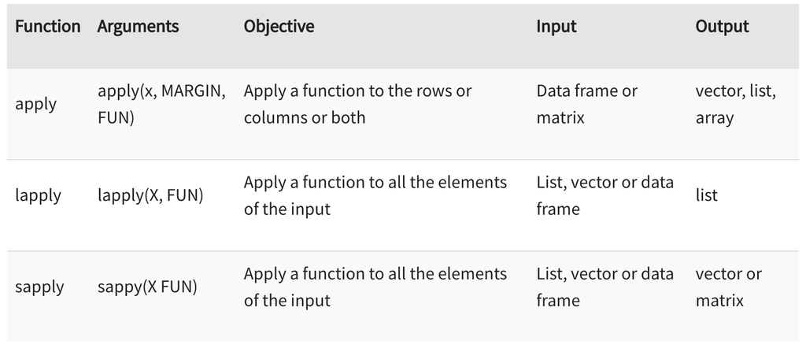